## Current parameters

The table below describes the parameters used for generating the pattern.

| parameter | value | description |
| --- | --- | --- |
| color_number | 16 | number of different colors or fabrics |
| colorspace | YUV | [advanced] colorspace to use in reducing the number of colors in the original picture (some examples are YUV, RGB, HSV) |
| colorspace_max_colors | 500 | [advanced] maximum number of colors returned after colorspace reduction |
| finished_size | 100 x 74 | finished quilt size, in inch |
| grid_block_size | 8 | block size in tiles (i.e. 8 for instructions for blocks of 8x8 tiles) |
| img_filename | fall_landscape.jpg | picture file to process (.jpg) |
| img_height | 750 | height in pixel of the image |
| img_width | 1000 | width in pixel of the image |
| tile_number_height | 37 | number of tiles across the height of the picture |
| tile_number_width | 50 | number of tiles to have across the width of the picture |
| tile_size | 2 | size in inch of each square tile (i.e. 2 for 2x2” tiles in finished quilt) |
| tile_width | 20 | tile width in pixel |

## Color reduction

Pictures contain often hundreds of colors, many very close in shades. It is necessary to simplify the color universe of the original picture before calculating the number of occurance of each color. Without that simplification, the dominant color shades might overwhelm the other colors and bias the final colorscheme.

Different pictures might behave differently with different colorspace reduction, try another `colospace` in the `config.yaml` file if the colors look off after reduction. The maximum number of color after reduction (`colorspace_max_colors` in the file `config.yaml`) can also be adjusted.

### Original picture

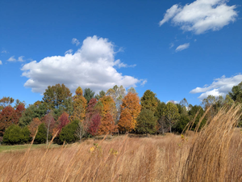

### After color reduction

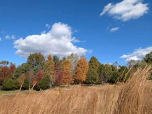

## Overview of tiled picture

Below is the result of tiling and color-clustering, to have at most 16 colors.

For easier quilt assembly, the full picture is divided in 8x8 tiles blocks.

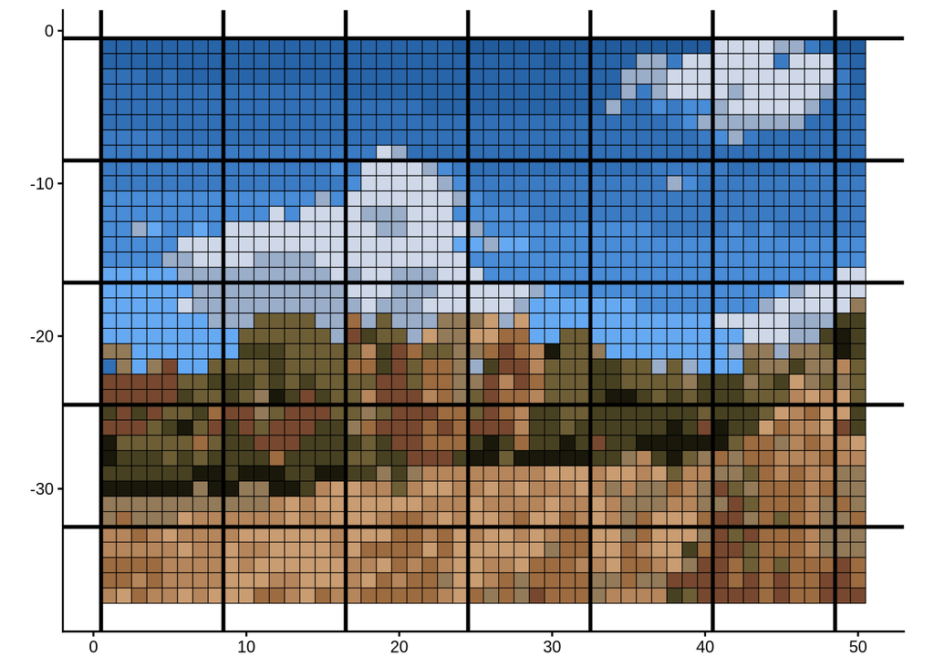

## Fabric requirements

Below is the swatch of colors with number of squares / tiles needed, and translated into yardage. Fat quarters are 18x22”. The yardage includes a 1/4” seam allowance.

Cut the specified number of 2.5” squares per color.

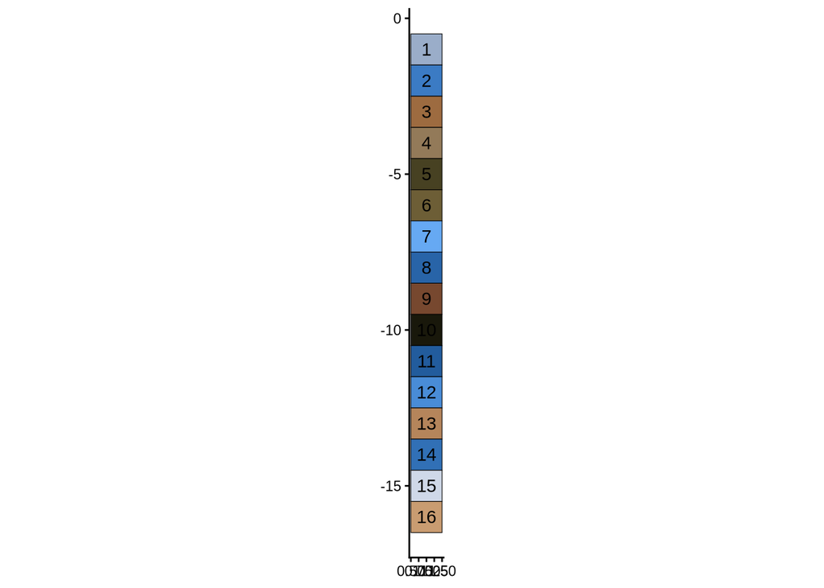

| color_name | number_of_tiles | number_of_fat_quarters |
| --- | --- | --- |
| 1 | 109 | 1.5138889 |
| 2 | 156 | 2.1666667 |
| 3 | 132 | 1.8333333 |
| 4 | 98 | 1.3611111 |
| 5 | 116 | 1.6111111 |
| 6 | 116 | 1.6111111 |
| 7 | 92 | 1.2777778 |
| 8 | 122 | 1.6944444 |
| 9 | 91 | 1.2638889 |
| 10 | 44 | 0.6111111 |
| 11 | 20 | 0.2777778 |
| 12 | 163 | 2.2638889 |
| 13 | 144 | 2.0000000 |
| 14 | 178 | 2.4722222 |
| 15 | 151 | 2.0972222 |
| 16 | 118 | 1.6388889 |

## General assembly remarks

For easier assembly, first sew together 8 tiles x 8 tiles blocks, then sew rows of blocks, and finally sew rows together.

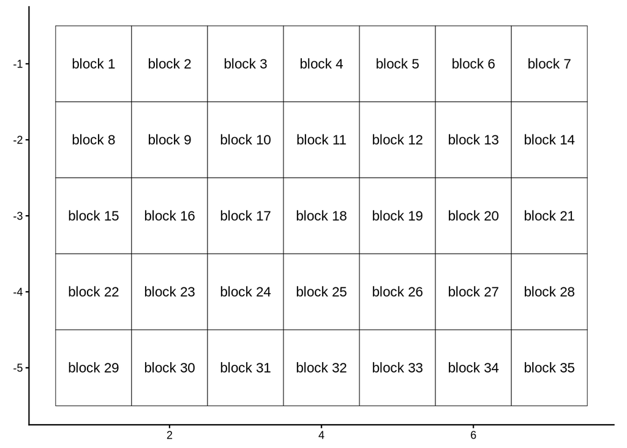

## Blocks assembly

Below are instructions for making each of the 8x8 blocks.

### Block 1

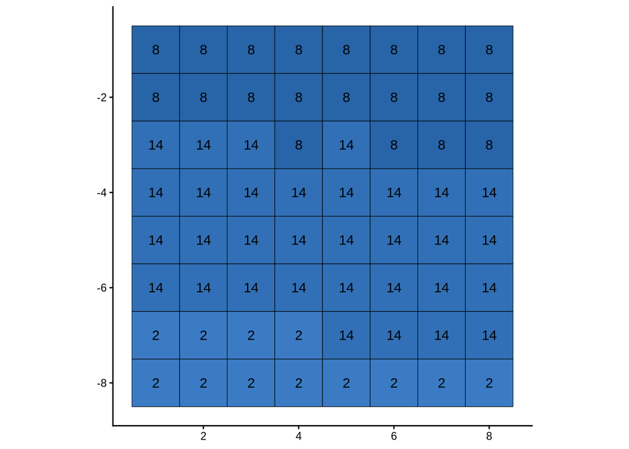

| color_name | number_of_tiles | number_of_fat_quarters |
| --- | --- | --- |
| 2 | 12 | 0.1666667 |
| 8 | 20 | 0.2777778 |
| 14 | 32 | 0.4444444 |

### Block 2

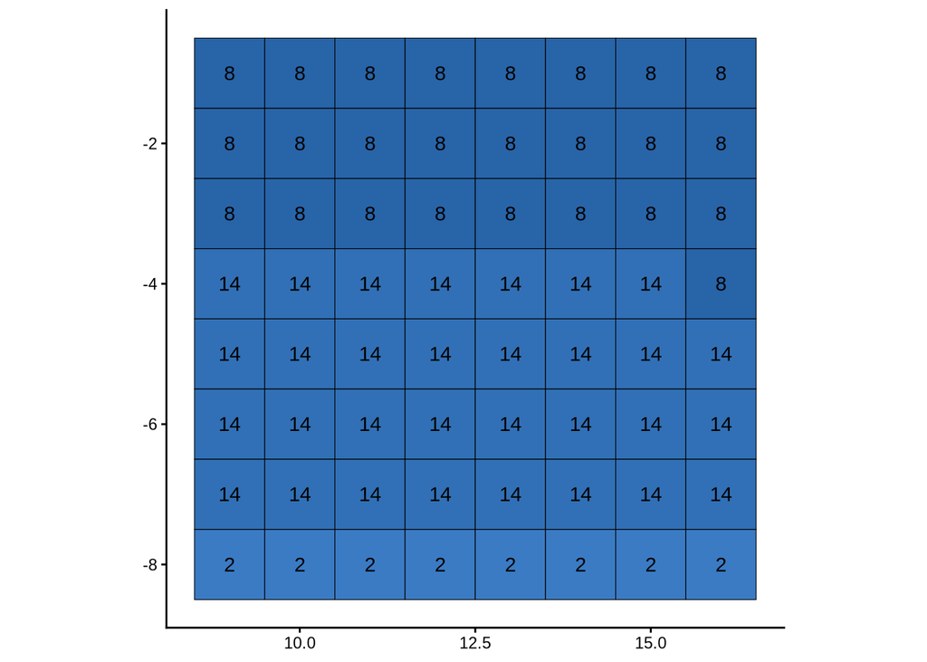

| color_name | number_of_tiles | number_of_fat_quarters |
| --- | --- | --- |
| 2 | 8 | 0.1111111 |
| 8 | 25 | 0.3472222 |
| 14 | 31 | 0.4305556 |

### Block 3

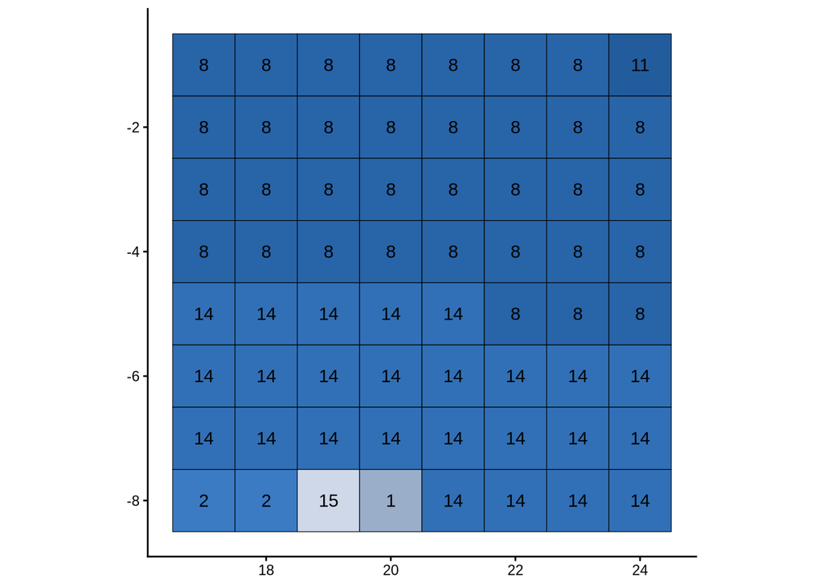

| color_name | number_of_tiles | number_of_fat_quarters |
| --- | --- | --- |
| 1 | 1 | 0.0138889 |
| 2 | 2 | 0.0277778 |
| 8 | 34 | 0.4722222 |
| 11 | 1 | 0.0138889 |
| 14 | 25 | 0.3472222 |
| 15 | 1 | 0.0138889 |

### Block 4

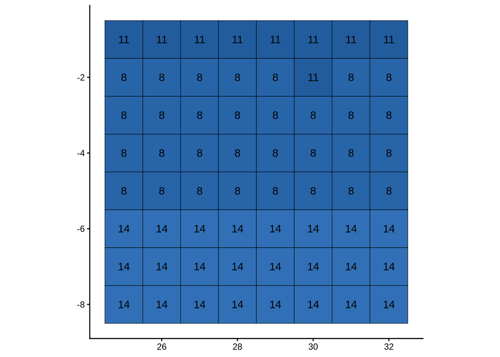

| color_name | number_of_tiles | number_of_fat_quarters |
| --- | --- | --- |
| 8 | 31 | 0.4305556 |
| 11 | 9 | 0.1250000 |
| 14 | 24 | 0.3333333 |

### Block 5

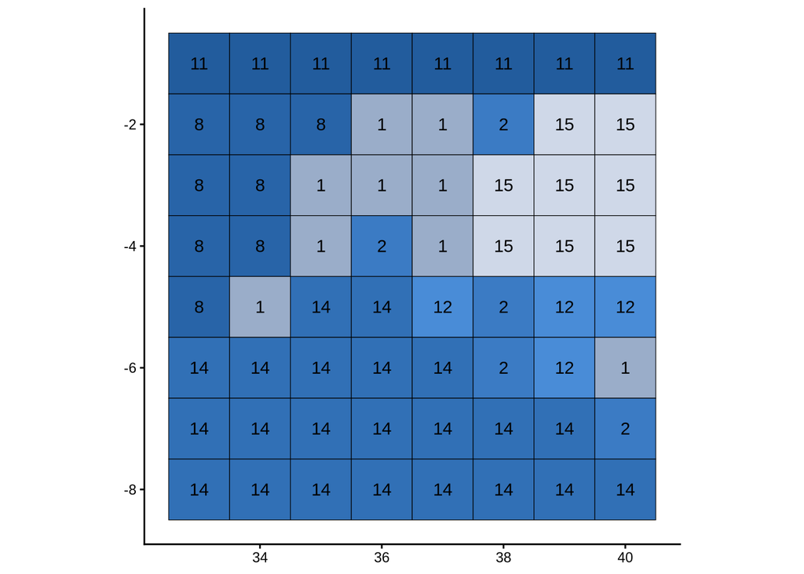

| color_name | number_of_tiles | number_of_fat_quarters |
| --- | --- | --- |
| 1 | 9 | 0.1250000 |
| 2 | 5 | 0.0694444 |
| 8 | 8 | 0.1111111 |
| 11 | 8 | 0.1111111 |
| 12 | 4 | 0.0555556 |
| 14 | 22 | 0.3055556 |
| 15 | 8 | 0.1111111 |

### Block 6

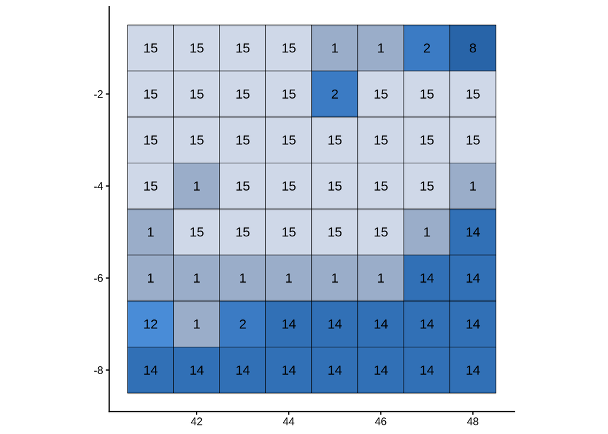

| color_name | number_of_tiles | number_of_fat_quarters |
| --- | --- | --- |
| 1 | 13 | 0.1805556 |
| 2 | 3 | 0.0416667 |
| 8 | 1 | 0.0138889 |
| 12 | 1 | 0.0138889 |
| 14 | 16 | 0.2222222 |
| 15 | 30 | 0.4166667 |

### Block 7

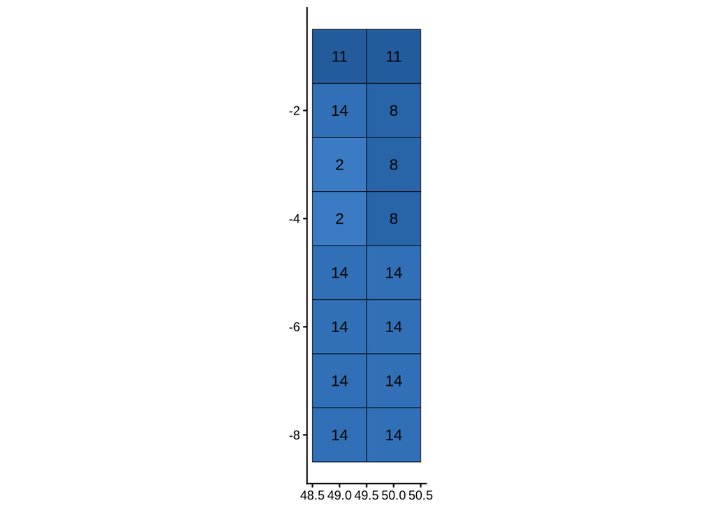

| color_name | number_of_tiles | number_of_fat_quarters |
| --- | --- | --- |
| 2 | 2 | 0.0277778 |
| 8 | 3 | 0.0416667 |
| 11 | 2 | 0.0277778 |
| 14 | 9 | 0.1250000 |

### Block 8

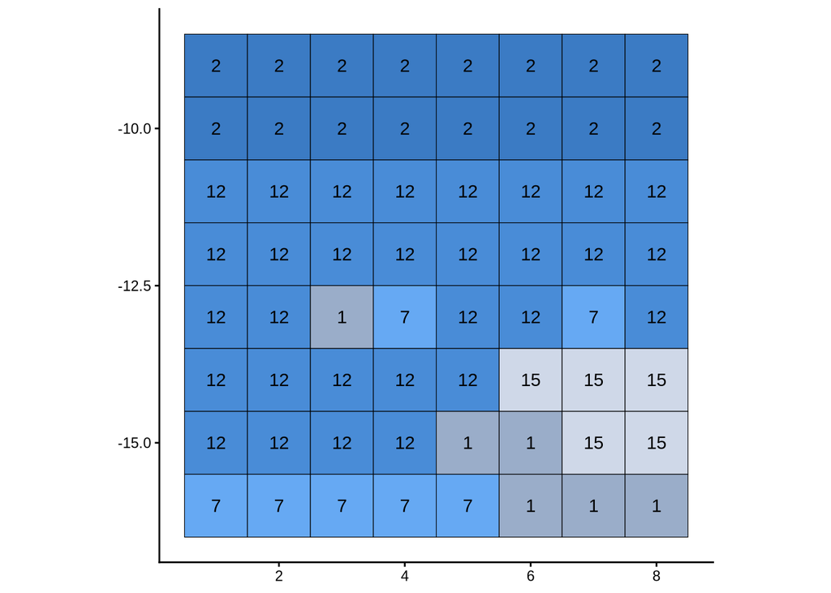

| color_name | number_of_tiles | number_of_fat_quarters |
| --- | --- | --- |
| 1 | 6 | 0.0833333 |
| 2 | 16 | 0.2222222 |
| 7 | 7 | 0.0972222 |
| 12 | 30 | 0.4166667 |
| 15 | 5 | 0.0694444 |

### Block 9

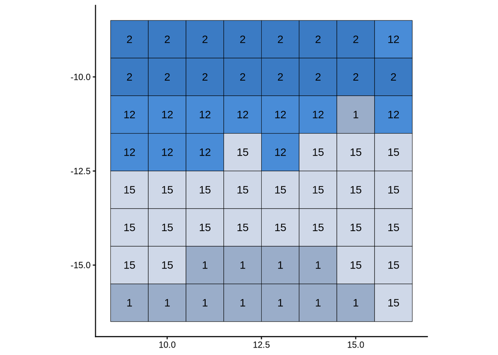

| color_name | number_of_tiles | number_of_fat_quarters |
| --- | --- | --- |
| 1 | 12 | 0.1666667 |
| 2 | 15 | 0.2083333 |
| 12 | 12 | 0.1666667 |
| 15 | 25 | 0.3472222 |

### Block 10

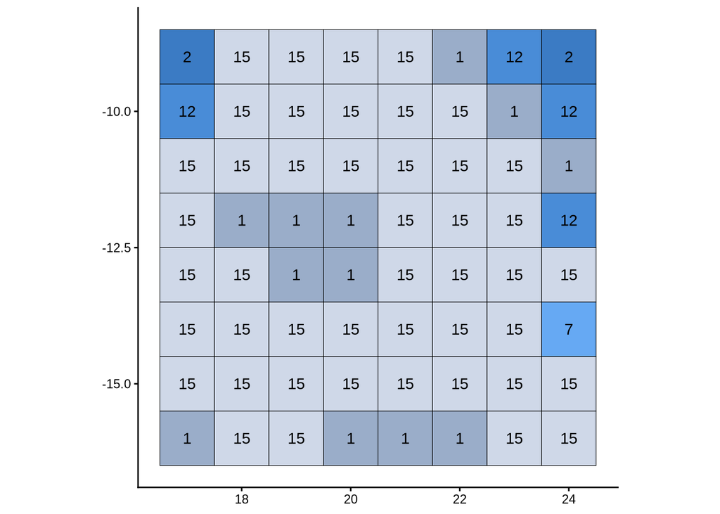

| color_name | number_of_tiles | number_of_fat_quarters |
| --- | --- | --- |
| 1 | 12 | 0.1666667 |
| 2 | 2 | 0.0277778 |
| 7 | 1 | 0.0138889 |
| 12 | 4 | 0.0555556 |
| 15 | 45 | 0.6250000 |

### Block 11

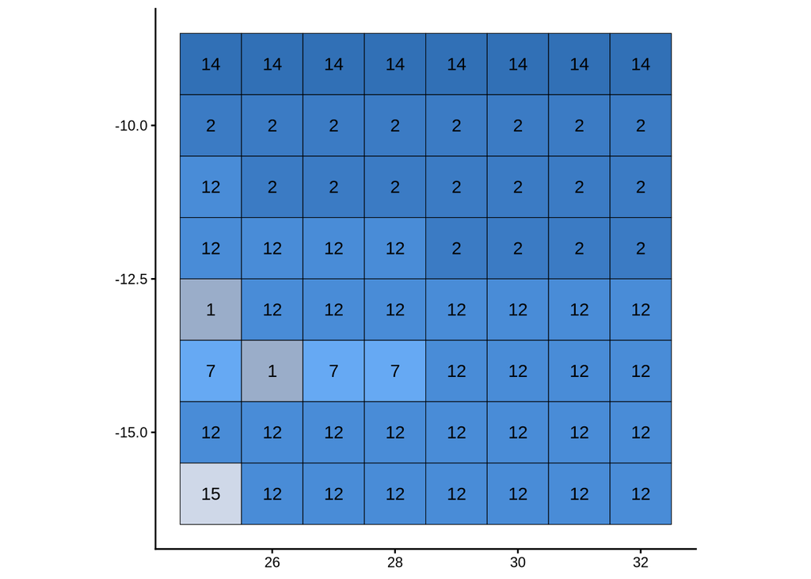

| color_name | number_of_tiles | number_of_fat_quarters |
| --- | --- | --- |
| 1 | 2 | 0.0277778 |
| 2 | 19 | 0.2638889 |
| 7 | 3 | 0.0416667 |
| 12 | 31 | 0.4305556 |
| 14 | 8 | 0.1111111 |
| 15 | 1 | 0.0138889 |

### Block 12

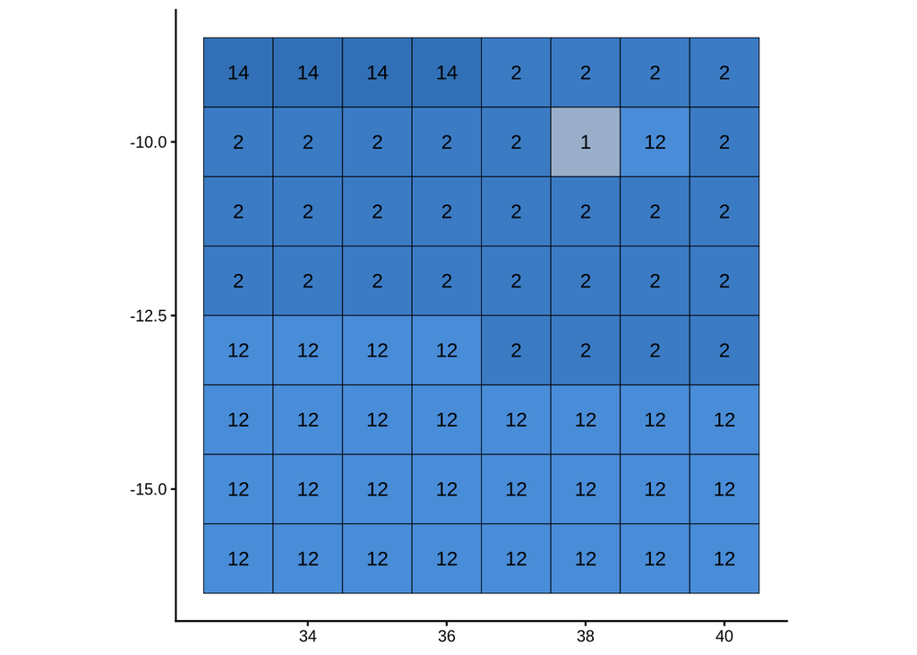

| color_name | number_of_tiles | number_of_fat_quarters |
| --- | --- | --- |
| 1 | 1 | 0.0138889 |
| 2 | 30 | 0.4166667 |
| 12 | 29 | 0.4027778 |
| 14 | 4 | 0.0555556 |

### Block 13

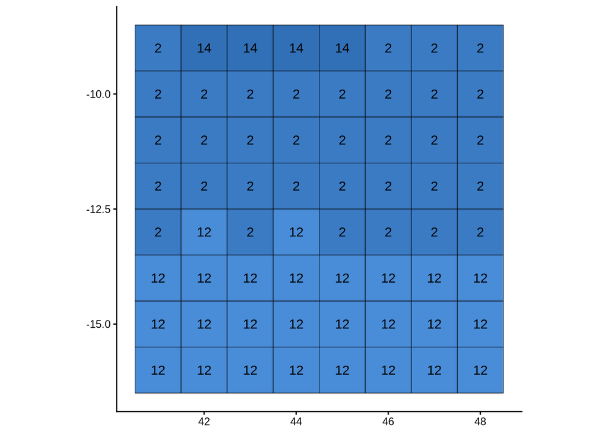

| color_name | number_of_tiles | number_of_fat_quarters |
| --- | --- | --- |
| 2 | 34 | 0.4722222 |
| 12 | 26 | 0.3611111 |
| 14 | 4 | 0.0555556 |

### Block 14

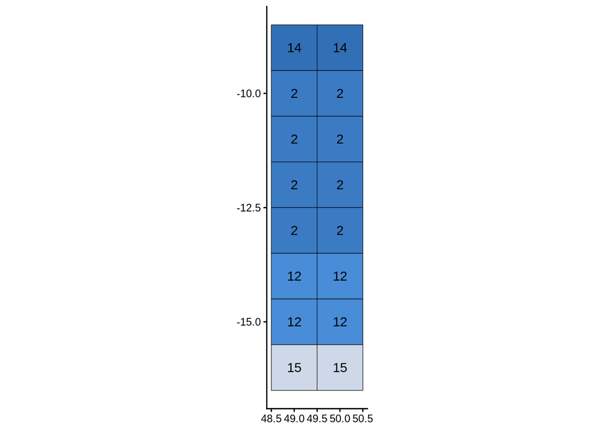

| color_name | number_of_tiles | number_of_fat_quarters |
| --- | --- | --- |
| 2 | 8 | 0.1111111 |
| 12 | 4 | 0.0555556 |
| 14 | 2 | 0.0277778 |
| 15 | 2 | 0.0277778 |

### Block 15

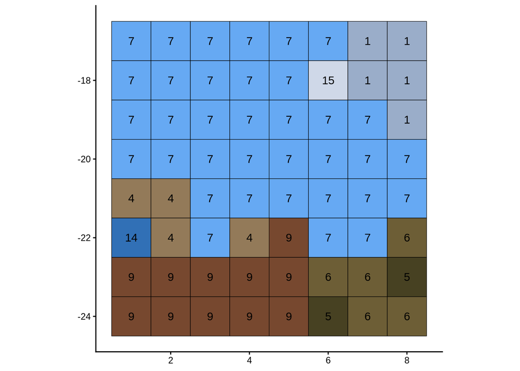

| color_name | number_of_tiles | number_of_fat_quarters |
| --- | --- | --- |
| 1 | 5 | 0.0694444 |
| 4 | 4 | 0.0555556 |
| 5 | 2 | 0.0277778 |
| 6 | 5 | 0.0694444 |
| 7 | 35 | 0.4861111 |
| 9 | 11 | 0.1527778 |
| 14 | 1 | 0.0138889 |
| 15 | 1 | 0.0138889 |

### Block 16

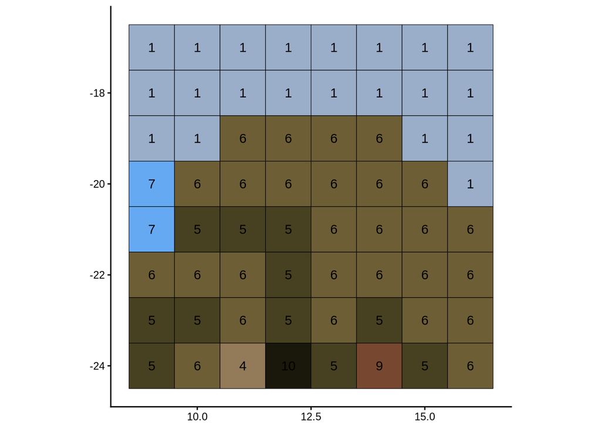

| color_name | number_of_tiles | number_of_fat_quarters |
| --- | --- | --- |
| 1 | 21 | 0.2916667 |
| 4 | 1 | 0.0138889 |
| 5 | 11 | 0.1527778 |
| 6 | 27 | 0.3750000 |
| 7 | 2 | 0.0277778 |
| 9 | 1 | 0.0138889 |
| 10 | 1 | 0.0138889 |

### Block 17

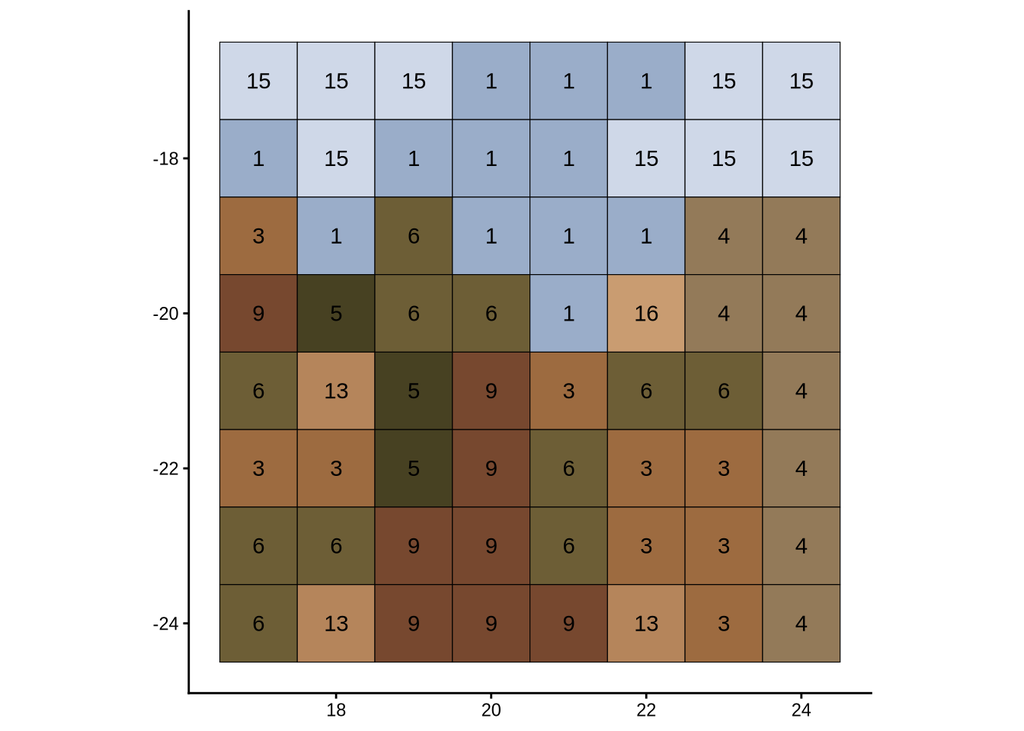

| color_name | number_of_tiles | number_of_fat_quarters |
| --- | --- | --- |
| 1 | 12 | 0.1666667 |
| 3 | 9 | 0.1250000 |
| 4 | 8 | 0.1111111 |
| 5 | 3 | 0.0416667 |
| 6 | 11 | 0.1527778 |
| 9 | 8 | 0.1111111 |
| 13 | 3 | 0.0416667 |
| 15 | 9 | 0.1250000 |
| 16 | 1 | 0.0138889 |

### Block 18

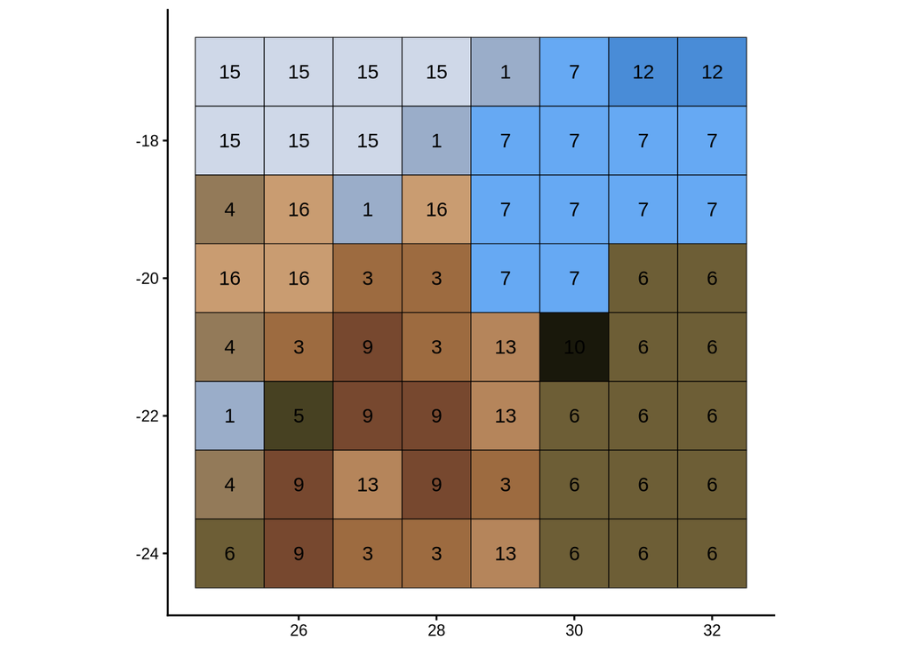

| color_name | number_of_tiles | number_of_fat_quarters |
| --- | --- | --- |
| 1 | 4 | 0.0555556 |
| 3 | 7 | 0.0972222 |
| 4 | 3 | 0.0416667 |
| 5 | 1 | 0.0138889 |
| 6 | 14 | 0.1944444 |
| 7 | 11 | 0.1527778 |
| 9 | 6 | 0.0833333 |
| 10 | 1 | 0.0138889 |
| 12 | 2 | 0.0277778 |
| 13 | 4 | 0.0555556 |
| 15 | 7 | 0.0972222 |
| 16 | 4 | 0.0555556 |

### Block 19

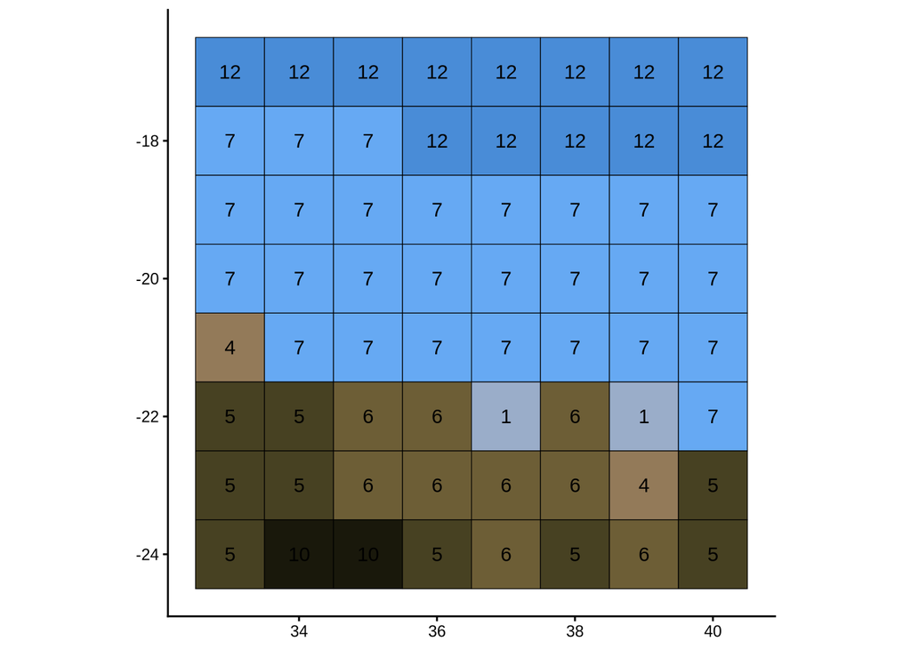

| color_name | number_of_tiles | number_of_fat_quarters |
| --- | --- | --- |
| 1 | 2 | 0.0277778 |
| 4 | 2 | 0.0277778 |
| 5 | 9 | 0.1250000 |
| 6 | 9 | 0.1250000 |
| 7 | 27 | 0.3750000 |
| 10 | 2 | 0.0277778 |
| 12 | 13 | 0.1805556 |

### Block 20

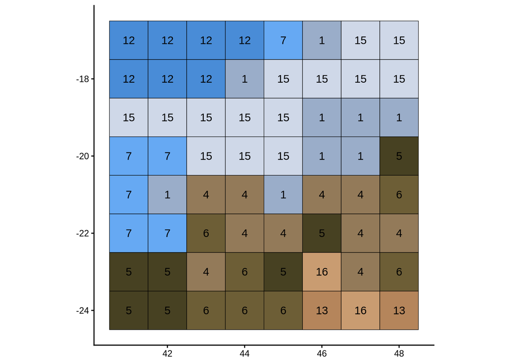

| color_name | number_of_tiles | number_of_fat_quarters |
| --- | --- | --- |
| 1 | 9 | 0.1250000 |
| 4 | 10 | 0.1388889 |
| 5 | 7 | 0.0972222 |
| 6 | 7 | 0.0972222 |
| 7 | 6 | 0.0833333 |
| 12 | 7 | 0.0972222 |
| 13 | 2 | 0.0277778 |
| 15 | 14 | 0.1944444 |
| 16 | 2 | 0.0277778 |

### Block 21

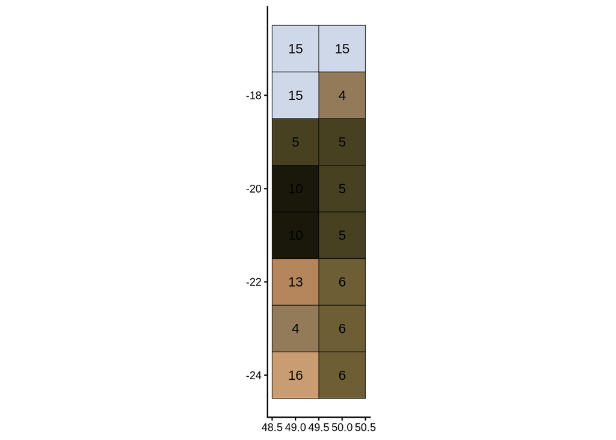

| color_name | number_of_tiles | number_of_fat_quarters |
| --- | --- | --- |
| 4 | 2 | 0.0277778 |
| 5 | 4 | 0.0555556 |
| 6 | 3 | 0.0416667 |
| 10 | 2 | 0.0277778 |
| 13 | 1 | 0.0138889 |
| 15 | 3 | 0.0416667 |
| 16 | 1 | 0.0138889 |

### Block 22

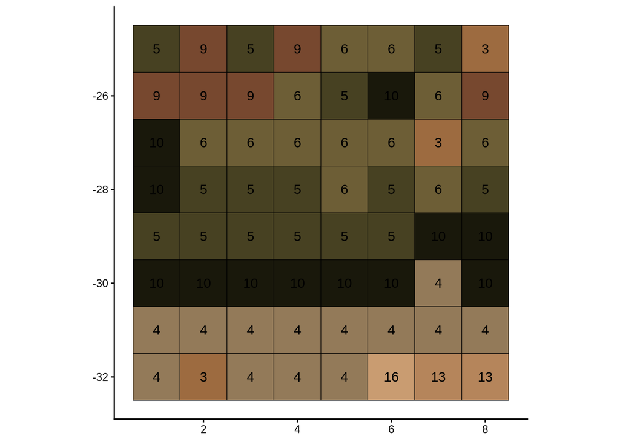

| color_name | number_of_tiles | number_of_fat_quarters |
| --- | --- | --- |
| 3 | 3 | 0.0416667 |
| 4 | 13 | 0.1805556 |
| 5 | 15 | 0.2083333 |
| 6 | 12 | 0.1666667 |
| 9 | 6 | 0.0833333 |
| 10 | 12 | 0.1666667 |
| 13 | 2 | 0.0277778 |
| 16 | 1 | 0.0138889 |

### Block 23

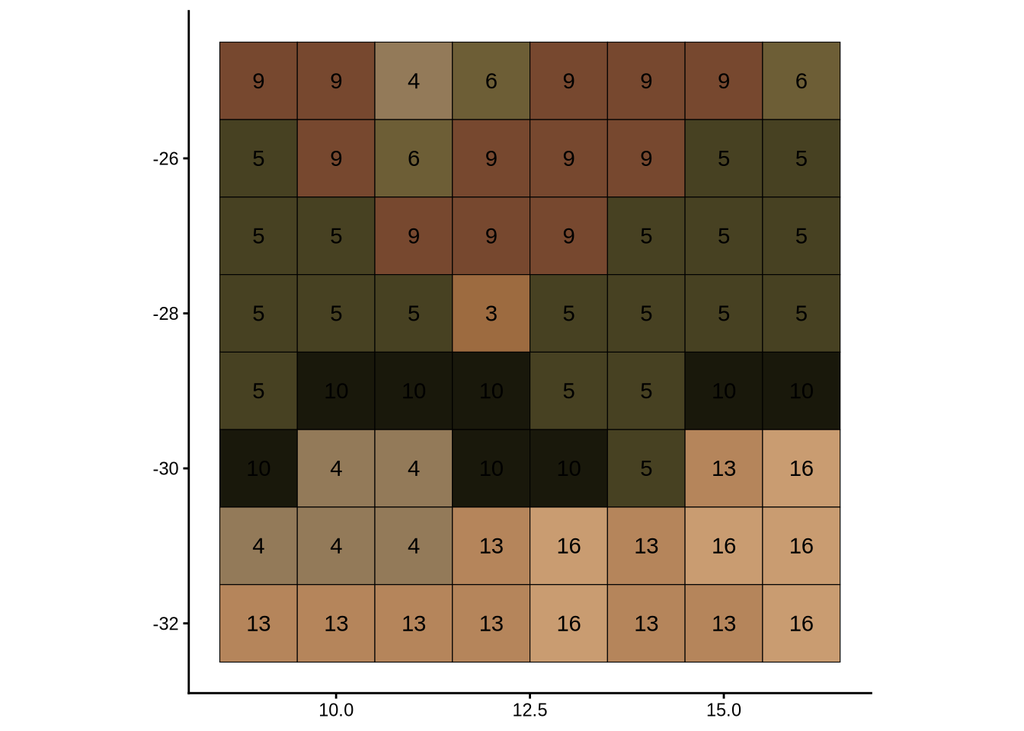

| color_name | number_of_tiles | number_of_fat_quarters |
| --- | --- | --- |
| 3 | 1 | 0.0138889 |
| 4 | 6 | 0.0833333 |
| 5 | 19 | 0.2638889 |
| 6 | 3 | 0.0416667 |
| 9 | 12 | 0.1666667 |
| 10 | 8 | 0.1111111 |
| 13 | 9 | 0.1250000 |
| 16 | 6 | 0.0833333 |

### Block 24

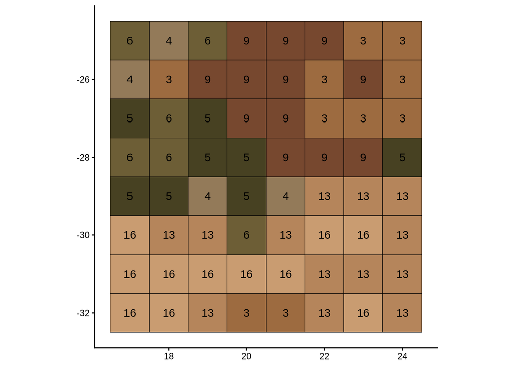

| color_name | number_of_tiles | number_of_fat_quarters |
| --- | --- | --- |
| 3 | 10 | 0.1388889 |
| 4 | 4 | 0.0555556 |
| 5 | 8 | 0.1111111 |
| 6 | 6 | 0.0833333 |
| 9 | 12 | 0.1666667 |
| 13 | 13 | 0.1805556 |
| 16 | 11 | 0.1527778 |

### Block 25

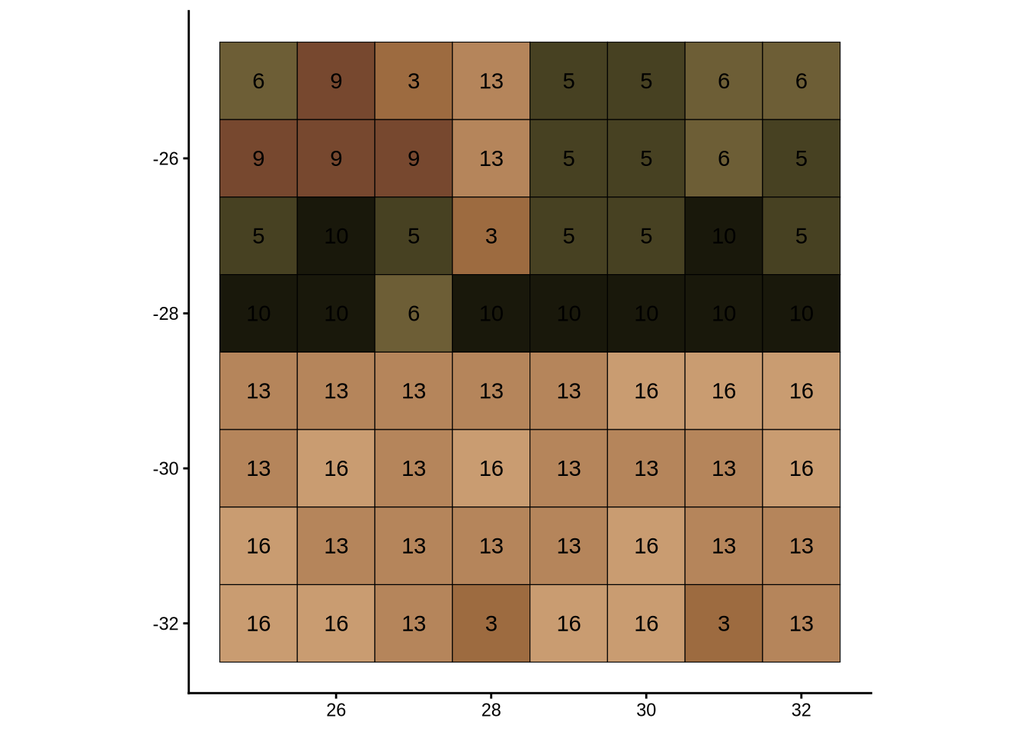

| color_name | number_of_tiles | number_of_fat_quarters |
| --- | --- | --- |
| 3 | 4 | 0.0555556 |
| 5 | 10 | 0.1388889 |
| 6 | 5 | 0.0694444 |
| 9 | 4 | 0.0555556 |
| 10 | 9 | 0.1250000 |
| 13 | 20 | 0.2777778 |
| 16 | 12 | 0.1666667 |

### Block 26

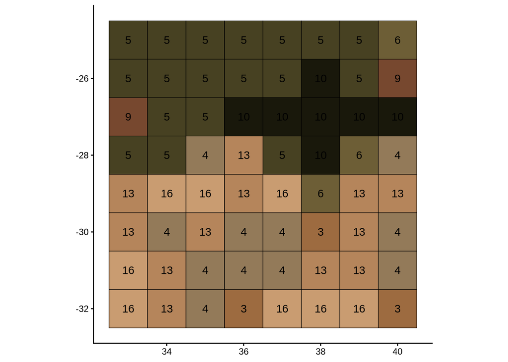

| color_name | number_of_tiles | number_of_fat_quarters |
| --- | --- | --- |
| 3 | 3 | 0.0416667 |
| 4 | 11 | 0.1527778 |
| 5 | 18 | 0.2500000 |
| 6 | 3 | 0.0416667 |
| 9 | 2 | 0.0277778 |
| 10 | 7 | 0.0972222 |
| 13 | 12 | 0.1666667 |
| 16 | 8 | 0.1111111 |